# Tarea 1

```r
library (tidyr)
library(ggplot2)
library(ggthemes)
require(gridExtra)
source("MM1_queue.R")
```

1. Sea $X$ el número de ’unos’ obtenido en $12$ lanzamientos de un dado honesto. Entonces $X$ tiene una distribución binomial. Calcular una tabla con los valores de la función de distribución para $x = 0, 1, ... , 12$ por dos métodos: usando la función cumsum y usando la función $pbinom$. También determinar cuánto vale $P(X > 7)$.
   - En este caso tenemos que $X \sim Bin\left(12,\frac{1}{6}\right)$, se quiere obtener la distribución de dicha variable aleatoria, comencemos por obtener la función de densidad y a partir de ella obtengamos la distribución:

     ```r
       bin_density = dbinom(0:12, 12, 1/6)
       bin_distribution_1 = cumsum(bin_density)
       distribution <- data.frame(bin_distribution_1, row.names = 0:12)
       knitr::kable(distribution)
     ```

     |  | bin_distribution_1 |
     | --- | --- |
     | 0 | 0.1121567 |
     | 1 | 0.3813326 |
     | 2 | 0.6774262 |
     | 3 | 0.8748219 |
     | 4 | 0.9636500 |
     | 5 | 0.9920750 |
     | 6 | 0.9987075 |
     | 7 | 0.9998445 |
     | 8 | 0.9999866 |
     | 9 | 0.9999992 |
     | 10 | 1.0000000 |
     | 11 | 1.0000000 |
     | 12 | 1.0000000 |

   - Ahora, utilizando el comando de R para obtener la distribución

     ```r
       bin_distribution_2 = pbinom(0:12,12,1/6)
       distribution <- data.frame(bin_distribution_2, row.names = 0:12)
       knitr::kable(distribution)
     ```

     |  | bin_distribution_2 |
     | --- | --- |
     | 0 | 0.1121567 |
     | 1 | 0.3813326 |
     | 2 | 0.6774262 |
     | 3 | 0.8748219 |
     | 4 | 0.9636500 |
     | 5 | 0.9920750 |
     | 6 | 0.9987075 |
     | 7 | 0.9998445 |
     | 8 | 0.9999866 |
     | 9 | 0.9999992 |
     | 10 | 1.0000000 |
     | 11 | 1.0000000 |
     | 12 | 1.0000000 |

   - Finalmente, determinamos $P(X > 7)$:

     ```r
       1 - pbinom(7, 12, 1/6)
     ```

     ```
     ## [1] 0.0001555443
     ```

     ```r
       sum(dbinom(8:12, 12, 1/6))
     ```

     ```
     ## [1] 0.0001555443
     ```

2. (Estaturas de presidentes gringos). En un artículo de Wikipedia, se reportan las estaturas de los Presidentes de los Estados Unidos y los de sus oponentes en elecciones. Se ha notado que mientras más alto seal el presidente típicamente gana la elección.
   - Comencemos por leer el Dataframe de el archivo csv obtenido de Wikipedia:

   ```r
      presidents_heights <- read.csv('presidents_heights.csv')
      knitr::kable(presidents_heights)
   ```

   | year | winner | winner_height | opponent | opponent_height |
   | --- | --- | --- | --- | --- |
   | 2008 | Barack Obama | 185 | John McCain | 175 |
   | 2004 | George W. Bush | 182 | John Kerry | 193 |
   | 2000 | George W. Bush | 182 | Al Gore | 185 |
   | 1996 | Bill Clinton | 188 | Bob Dole | 187 |
   | 1992 | Bill Clinton | 188 | George H.W. Bush | 188 |
   | 1988 | George H.W. Bush | 188 | Michael Dukakis | 173 |
   | 1984 | Ronald Reagan | 185 | Walter Mondale | 180 |
   | 1980 | Ronald Reagan | 185 | Jimmy Carter | 177 |
   | 1976 | Jimmy Carter | 177 | Gerald Ford | 183 |
   | 1972 | Richard Nixon | 182 | George McGovern | 185 |
   | 1968 | Richard Nixon | 182 | Hubert Humphrey | 180 |
   | 1964 | Lyndon B. Johnson | 192 | Barry Goldwater | 180 |
   | 1960 | John F. Kennedy | 185 | Richard Nixon | 182 |
   | 1956 | Dwight D. Eisenhower | 179 | Adlai Stevenson II | 178 |
   | 1952 | Dwight D. Eisenhower | 179 | Adlai Stevenson II | 178 |
   | 1948 | Harry S. Truman | 175 | Thomas Dewey | 173 |

   - Y realizamos la gráfica:

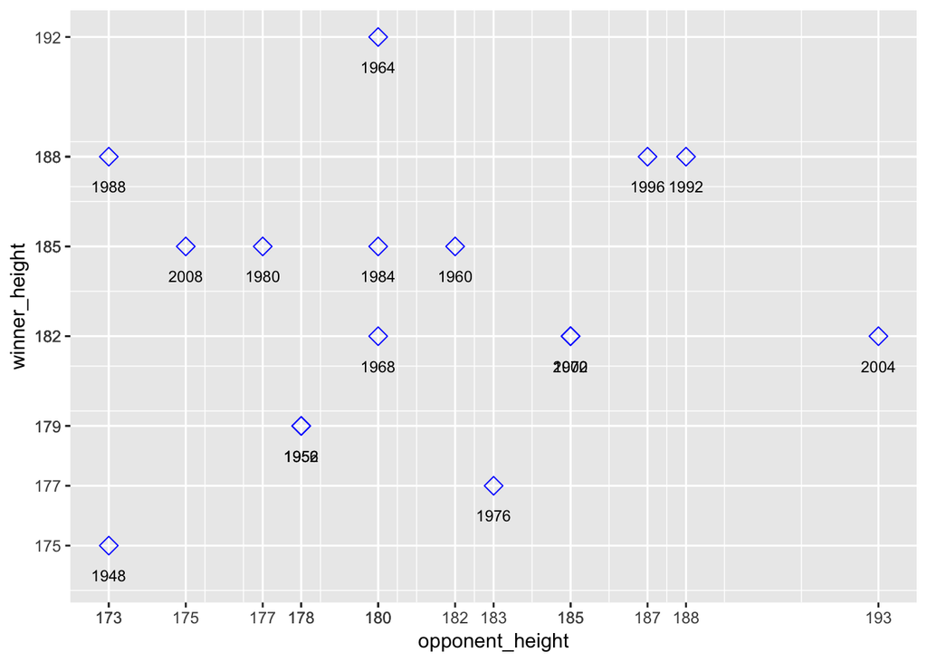

   ```r
      ggplot(presidents_heights, aes(opponent_height, winner_height)) +
          scale_x_continuous(breaks = presidents_heights$opponent_height) +
          scale_y_continuous(breaks = presidents_heights$winner_height) +
          geom_point(aes(opponent_height, winner_height) , color = "blue", shape = 5, size=3) +
          geom_text(aes(label=year),nudge_y = -1, size=3)
   ```

   + Y otro tipo de gráfica:

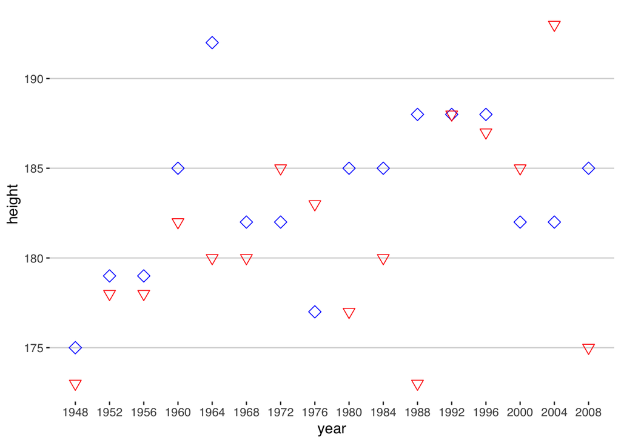

   ```r
      ggplot(presidents_heights, aes(year, height)) +
          scale_x_continuous(breaks = presidents_heights$year) +
          geom_point(aes(year, winner_height) , color = "blue", shape = 5, size=3) +
          geom_point(aes(year, opponent_height), color = "red", shape = 6, size=3) +
         theme_hc()
   ```

3. La función $rpois$ genera observaciones aleatorias de una distribución Poisson. Usen la función $rpois$ para simular un número grande $(n = 1000, \ n = 10000)$ de muestras Poisson con parámetro $\lambda = 0.61.$ Encuentren la función de masa de probabilidad, media, y varianza para las muestras. Comparen con los valores teóricos de la densidad Poisson.

- Comencemos por obtener la muestra con $n=1000$

  ```r
      lambda = .61
      writeLines(paste('Valores teóricos:\nMedia   : ', lambda, ' \nVarianza :', lambda))
  ```

  ```
  ## Valores teóricos:
  ## Media   :  0.61
  ## Varianza : 0.61
  ```

  ```r
      pois = rpois(1000, lambda)
      writeLines(paste('Con n = 1000:\nMedia muestral    : ', mean(pois), ' \nVarianza muestral :', var(pois)))
  ```

  ```
  ## Con n = 1000:
  ## Media muestral    :  0.617
  ## Varianza muestral : 0.5888998998999
  ```

  Donde la tabla de densidad de la muestra contra la densidad teórica de la distribución es:

  ```r
      count <- data.frame(table(pois))
      count$Freq = count$Freq/1000
      m = max(pois)
      count$teorica = dpois(0:m, .61)
      count$error_absoluto = abs(count$teorica - count$Freq)

      knitr::kable(count)
  ```

  | pois | Freq | teorica | error_absoluto |
  | --- | --- | --- | --- |
  | 0 | 0.535 | 0.5433509 | 0.0083509 |
  | 1 | 0.333 | 0.3314440 | 0.0015560 |
  | 2 | 0.116 | 0.1010904 | 0.0149096 |
  | 3 | 0.012 | 0.0205551 | 0.0085551 |
  | 4 | 0.004 | 0.0031346 | 0.0008654 |

  Finalmente, graficamos para tener una comparación visual

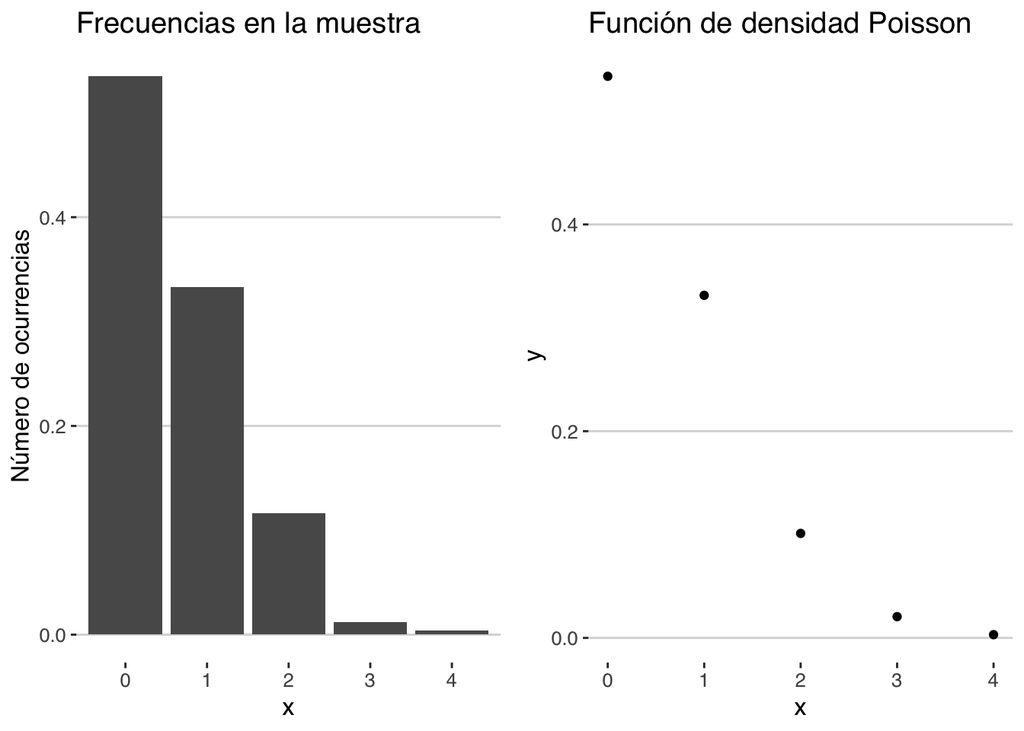

  ```r
      expetimental = ggplot(count, aes(pois, Freq)) +
        labs(title="Frecuencias en la muestra", y="Número de ocurrencias", x="x") +
        geom_bar(stat="identity") + theme_hc()

      teorica = ggplot(data.frame(x = c(0:m) ), aes(x = x)) +
        labs(title="Función de densidad Poisson", y="y", x="x") +
          stat_function( geom="point", n=m+1, fun=dpois, args=list(lambda)) +
          theme_hc()

      grid.arrange(expetimental,teorica,ncol=2)
  ```

  ```r
      lambda = .61
      writeLines(paste('Valores teóricos:\nMedia   : ', lambda, ' \nVarianza :', lambda))
  ```

  ```
  ## Valores teóricos:
  ## Media   :  0.61
  ## Varianza : 0.61
  ```

  ```r
      pois = rpois(10000, lambda)
      writeLines(paste('Con n = 10000:\nMedia muestral    : ', mean(pois), ' \nVarianza muestral :', var(pois)))
  ```

  ```
  ## Con n = 10000:
  ## Media muestral    :  0.6092
  ## Varianza muestral : 0.589334293429343
  ```

  Donde la tabla de densidad de la muestra contra la densidad teórica de la distribución es:

  ```r
      count <- data.frame(table(pois))
      count$Freq = count$Freq/10000
      m = max(pois)
      count
  ```

  ```
  ##   pois   Freq
  ## 1    0 0.5375
  ## 2    1 0.3414
  ## 3    2 0.0984
  ## 4    3 0.0202
  ## 5    4 0.0021
  ## 6    5 0.0004
  ```

  ```r
      count$teorica = dpois(0:m, .61)
      count$error_absoluto = abs(count$teorica - count$Freq)

      knitr::kable(count)
  ```

  | pois | Freq | teorica | error_absoluto |
  | --- | --- | --- | --- |
  | 0 | 0.5375 | 0.5433509 | 0.0058509 |
  | 1 | 0.3414 | 0.3314440 | 0.0099560 |
  | 2 | 0.0984 | 0.1010904 | 0.0026904 |
  | 3 | 0.0202 | 0.0205551 | 0.0003551 |
  | 4 | 0.0021 | 0.0031346 | 0.0010346 |
  | 5 | 0.0004 | 0.0003824 | 0.0000176 |

  Finalmente, graficamos para tener una comparación visual

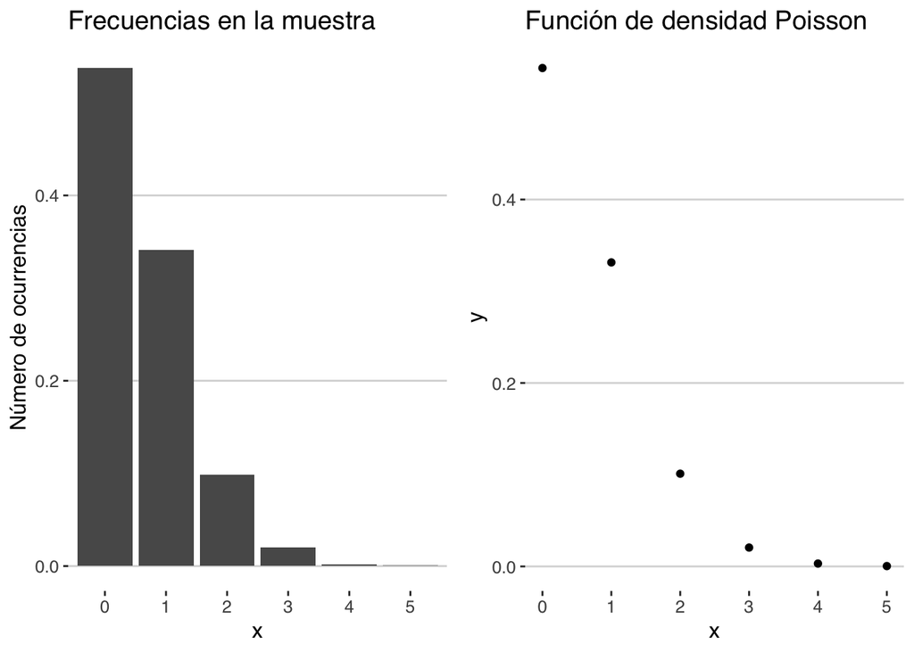

  ```r
      expetimental = ggplot(count, aes(pois, Freq)) +
        labs(title="Frecuencias en la muestra", y="Número de ocurrencias", x="x") +
        geom_bar(stat="identity") + theme_hc()

      teorica = ggplot(data.frame(x = c(0:m) ), aes(x = x)) +
        labs(title="Función de densidad Poisson", y="y", x="x") +
          stat_function( geom="point", n=m+1, fun=dpois, args=list(lambda)) +
          theme_hc()

      grid.arrange(expetimental,teorica,ncol=2)
  ```

   ```r
       sd.n <- function(X, insesgado = FALSE){

         media = mean(X)
           if (insesgado == TRUE){
             var = sum( (X - media )^2 )/ (length(X)-1)
           }
           else{
             var =  sum( (X - media )^2 )/ (length(X))
           }

           return (var)
       }
   ```

   Y comparando dicha función con la de R:

   ```r
     var(pois)
   ```

   ```
   ## [1] 0.5893343
   ```

   ```r
     sd.n(pois, insesgado=TRUE)
   ```

   ```
   ## [1] 0.5893343
   ```

   ```r
     sd.n(pois)
   ```

   ```
   ## [1] 0.5892754
   ```

5. Escriban una función norma que calcule la norma Euclideana de un vector numerico de longitud $n$. Evaluar la norma de los vectores $(0, 0, 0, 1)$, $(2, 5, 2, 4)$ y $(1, 2, 3, 4, 5, 6, 7, 8, 9, 10)$

   ```r
       norm_2 <- function(x){
           sqrt(sum(x^2))
       }

     v1 = c(0,0,0,1)
     v2 = c(2, 5, 2, 4)
     v3 = c(1, 2, 3, 4, 5, 6, 7, 8, 9, 10)

     norm_2( v1 )
   ```

   ```
   ## [1] 1
   ```

   ```r
     norm_2( v2 )
   ```

   ```
   ## [1] 7
   ```

   ```r
     norm_2( v3 )
   ```

   ```
   ## [1] 19.62142
   ```

6. Usar la función curve para graficar la función $f(x) = \frac{e^{-x^2}}{1 + x^2}$ en el intervalo $0 \leq x \leq 10$. Luego usar la función integrate para calcular el valor de la integral:
$$\int_{0}^{\infty} \frac{e^{-x^2}}{1 + x^2}$$
El límite superior se especifica usando el argumento upper=Inf en la función integrate.

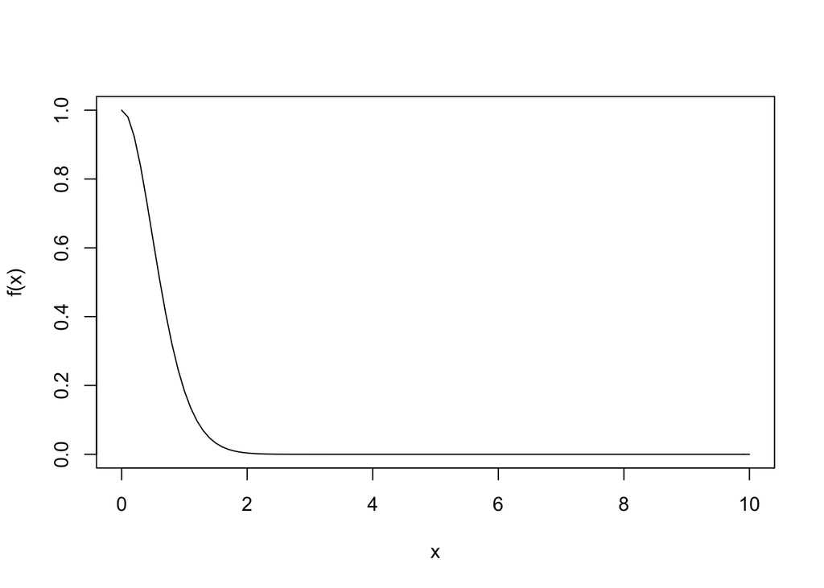

```r
  f <- function(x){
      exp(-(x^2))/(1 + x^2)
  }

  curve(f, from = 0, to = 10)
```

```r
  integrate(f, lower = 0, upper = Inf)
```

```
## 0.6716467 with absolute error < 8.3e-05
```

7. Construir una matriz con 10 renglones y 2 columnas que contienen datos provenientes de una normal estándar: $x$ $<-$ matrix(rnorm(20),10,2) Esta es una muestra de 10 observaciones de una distribución normal bivariada. Usen la función apply y la función norma que crearon en un ejercicio anterior para calcular las normas euclideanas para cada una de las 10 observaciones.

   ```r
   x <- matrix(rnorm(20),10,2)
   x
   ```

   ```
   ##              [,1]        [,2]
   ##  [1,]  0.80059978 -0.65986405
   ##  [2,] -0.10693873 -2.37479948
   ##  [3,]  0.04196669  1.44358129
   ##  [4,]  0.58784460 -0.02356833
   ##  [5,] -0.11951493  0.35862778
   ##  [6,] -0.70910616 -1.19704217
   ##  [7,]  0.88080000 -2.12039329
   ##  [8,]  0.80546050 -0.19024733
   ##  [9,]  0.46930680 -1.60449453
   ## [10,] -1.01898348 -0.25640938
   ```

   ```r
   apply(x, 1, norm_2)
   ```

   ```
   ##  [1] 1.0374876 2.3772060 1.4441912 0.5883169 0.3780181 1.3913093 2.2960567
   ##  [8] 0.8276235 1.6717211 1.0507488
   ```

8. Los siguientes datos describen el factor de desgaste de papel manufacturado bajo diferentes presiones durante el prensado. Cuatro hojas de papel fueron seleccionadas y probadas para cada uno de los cinco lotes manufacturados, Hacer un boxplot para comparar los diferentes factores de resistencia para cada presión.

   ```r
     a = c(35.0,35.0,35.0,35.0,49.5,49.5,49.5,49.5,70.0,70.0,70.0,
           70.0,99.0,99.0,99.0,99.0,140.0,140.0,140.0,140.0)
     b = c(112,119,117,113,108,99,112,118,120,106,102,109,110,101,99,104,100,102,96,101)
     desgaste <- data.frame("Presion" = a, "Factor de resistencia" = b)
     knitr::kable(desgaste)
   ```

   | Presion | Factor.de.resistencia |
   | --- | --- |
   | 35.0 | 112 |
   | 35.0 | 119 |
   | 35.0 | 117 |
   | 35.0 | 113 |
   | 49.5 | 108 |
   | 49.5 | 99 |
   | 49.5 | 112 |
   | 49.5 | 118 |
   | 70.0 | 120 |
   | 70.0 | 106 |
   | 70.0 | 102 |
   | 70.0 | 109 |
   | 99.0 | 110 |
   | 99.0 | 101 |
   | 99.0 | 99 |
   | 99.0 | 104 |
   | 140.0 | 100 |
   | 140.0 | 102 |
   | 140.0 | 96 |
   | 140.0 | 101 |

   Y creamos la boxplot:

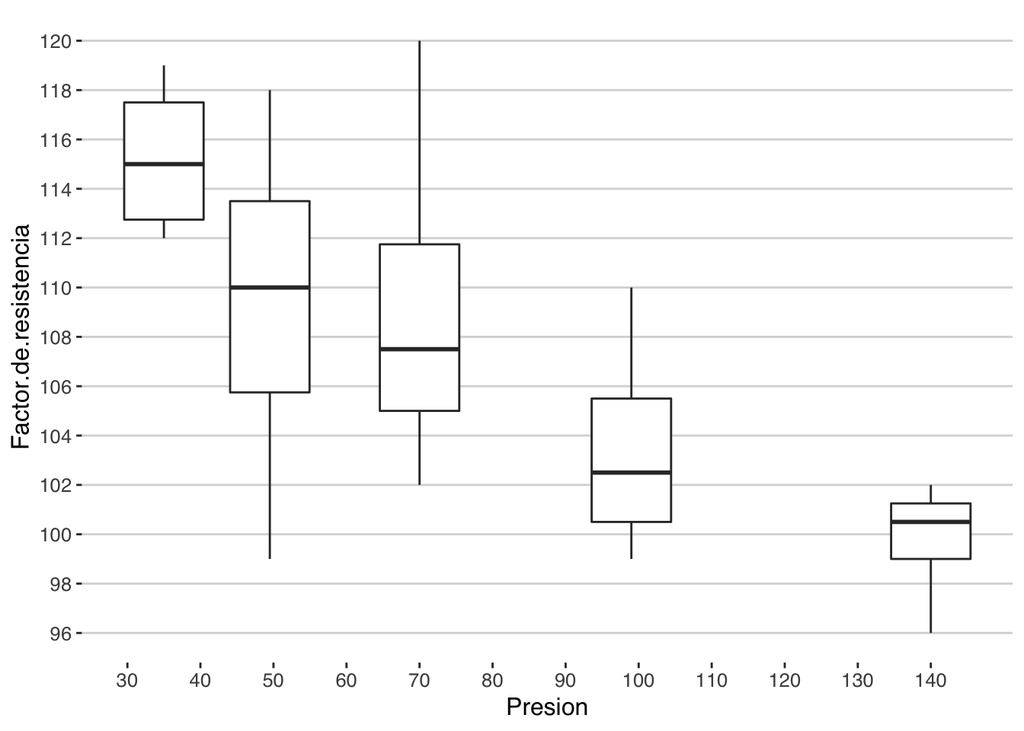

   ```r
      ggplot(desgaste, aes(group = Presion, x = Presion, y = Factor.de.resistencia)) +
           geom_boxplot() +
           scale_x_continuous(breaks = pretty(desgaste$Presion, n = 10)) +
           scale_y_continuous(breaks = pretty(desgaste$Factor.de.resistencia, n = 10)) +
           theme_hc()
   ```

9. Relacionado con el modelo de línea de espera. Incorporar las variables:
   - El tiempo total promedio de los n clientes en el sistema (‘promedio_tiempo_en_sistema’)
   - La longitud máxima de la cola (‘long_max_cola’)
   - La máxima espera en cola (‘max_espera’)

   Y ejecutar el modelo 100 veces con $\lambda A = 5$, $\lambda S = 4$ y $n = 1000$ y hacer un histograma para cada una de las estadísticas de desempeño, y calcular estadísticas descriptivas (media, varianza y coeficiente de variación, min, max, etc) para cada una de ellas.

   Obteniendo los resultados de las medidas descriptivas para las 100 simulaciones:

   ```r
     df <- data.frame(0,0,0,0,0,0)
     names(df)<-c("Prom_espera","Utilizacion","Prom_clientes", "Promedio_en_sistema", 'Long_max', 'Max_espera')

     for (i in 1:100){
       ans = mm1(lambdaA = 5, lambdaS = 4, n = 1000)
       df[nrow(df) + 1,] = c(ans[1:6])
     }
     df <- data.frame(df[-1, ])
     row.names(df) <- NULL
     knitr::kable(head(df))
   ```

   | Prom_espera | Utilizacion | Prom_clientes | Promedio_en_sistema | Long_max | Max_espera |
   | --- | --- | --- | --- | --- | --- |
   | 13.452717 | 80.81772 | 2.721548 | 17.44757 | 17 | 69.18109 |
   | 11.730200 | 73.91084 | 2.347400 | 15.42360 | 19 | 78.71270 |
   | 10.478161 | 76.00552 | 2.088352 | 14.29168 | 17 | 57.78728 |
   | 12.613823 | 81.68420 | 2.558779 | 16.64055 | 13 | 61.35644 |
   | 12.294615 | 77.85488 | 2.502747 | 16.11920 | 14 | 58.12842 |
   | 8.783903 | 75.89011 | 1.791791 | 12.50427 | 13 | 57.62176 |

   Mostrando estadísticas descriptivas

   ```r
     summary(df)
   ```

   ```
   ##   Prom_espera      Utilizacion    Prom_clientes    Promedio_en_sistema
   ##  Min.   : 8.784   Min.   :73.32   Min.   : 1.746   Min.   :12.50
   ##  1st Qu.:12.264   1st Qu.:77.27   1st Qu.: 2.422   1st Qu.:16.16
   ##  Median :14.090   Median :79.64   Median : 2.800   Median :18.10
   ##  Mean   :15.744   Mean   :79.75   Mean   : 3.149   Mean   :19.75
   ##  3rd Qu.:17.318   3rd Qu.:81.92   3rd Qu.: 3.469   3rd Qu.:21.42
   ##  Max.   :58.007   Max.   :87.55   Max.   :11.880   Max.   :62.18
   ##     Long_max       Max_espera
   ##  Min.   :11.00   Min.   : 48.60
   ##  1st Qu.:16.00   1st Qu.: 63.04
   ##  Median :17.00   Median : 74.02
   ##  Mean   :18.89   Mean   : 80.36
   ##  3rd Qu.:20.00   3rd Qu.: 91.55
   ##  Max.   :46.00   Max.   :210.76
   ```

   Y finalmente, graficando:

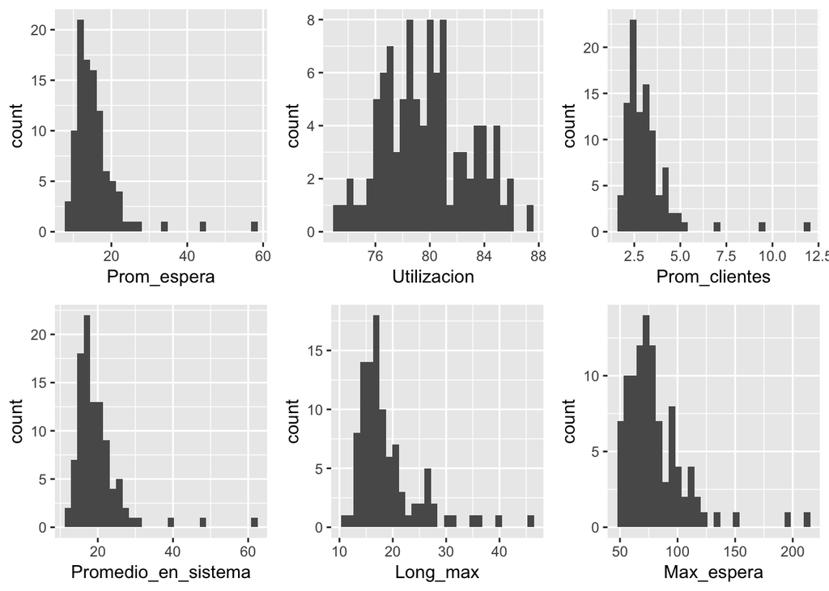

   ```r
   Promedio_espera_hist    = ggplot(df, aes(Prom_espera)) +
                           geom_histogram()
   Utilizacion_hist        = ggplot(df, aes(Utilizacion)) +
                               geom_histogram()
   Promedio_clientes_hist  = ggplot(df, aes(Prom_clientes)) +
                               geom_histogram()
   tiempo_en_sistema_hist  = ggplot(df, aes(Promedio_en_sistema)) +
                               geom_histogram()
   Long_max_cola_hist      = ggplot(df, aes(Long_max)) +
                               geom_histogram()
   Max_espera_en_cola_hist = ggplot(df, aes(Max_espera)) +
                               geom_histogram()

   grid.arrange(Promedio_espera_hist, Utilizacion_hist,
                Promedio_clientes_hist, tiempo_en_sistema_hist,
                Long_max_cola_hist, Max_espera_en_cola_hist,
                ncol=3)
   ```